# Quick Project 1 Technical Appendix

Jordan Gropper

7/7/21

# 1 set up data, tidy data, and EDA

```r
#install.packages("remotes")
#remotes::install_github("MattCowgill/ggannotate")
library(ggplot2)
library(gridExtra) # use to put graphs together in the same frame
library(janitor)
library(knitr)
library(GGally)
library(scales) # to get $ and , on axis in graph
library(tidyverse)
library(corrplot)#used for correlation plot with good looks below
```

# 2 Load and transform data

```r
houses <- read.csv("qp1_data.csv")#read data into environment and assign to variable

houses <- houses %>%
  mutate(living_sqft_price = price/sqft_living)

houses <- houses %>%
  mutate(lot_sqft_price = price/sqft_lot)
#class(living_sqft_price)
```

# 3 Base EDA Step 1: Uni-variate non-graphical EDA

```r
head(houses, 10)#check first ten
```

```
##      price bedrooms bathrooms sqft_living sqft_lot floors waterfront view grade
## 1   221900        3      1.00        1180     5650      1          0    0     7
## 2   538000        3      2.25        2570     7242      2          0    0     7
## 3   180000        2      1.00         770    10000      1          0    0     6
## 4   604000        4      3.00        1960     5000      1          0    0     7
## 5   510000        3      2.00        1680     8080      1          0    0     8
## 6  1230000        4      4.50        5420   101930      1          0    0    11
## 7   257500        3      2.25        1715     6819      2          0    0     7
## 8   291850        3      1.50        1060     9711      1          0    0     7
## 9   229500        3      1.00        1780     7470      1          0    0     7
## 10  323000        3      2.50        1890     6560      2          0    0     7
##    condition yr_built yr_renovated zip_code living_sqft_price lot_sqft_price
## 1          3     1955            0    98178          188.0508       39.27434
## 2          3     1951         1991    98125          209.3385       74.28887
## 3          3     1933            0    98028          233.7662       18.00000
## 4          5     1965            0    98136          308.1633      120.80000
## 5          3     1987            0    98074          303.5714       63.11881
## 6          3     2001            0    98053          226.9373       12.06710
## 7          3     1995            0    98003          150.1458       37.76214
## 8          3     1963            0    98198          275.3302       30.05355
## 9          3     1960            0    98146          128.9326       30.72289
## 10         3     2003            0    98038          170.8995       49.23780
```

```r
str(houses)#check structure
```

```
## 'data.frame':    21613 obs. of  15 variables:
##  $ price            : num  221900 538000 180000 604000 510000 ...
##  $ bedrooms         : int  3 3 2 4 3 4 3 3 3 3 ...
##  $ bathrooms        : num  1 2.25 1 3 2 4.5 2.25 1.5 1 2.5 ...
##  $ sqft_living      : int  1180 2570 770 1960 1680 5420 1715 1060 1780 1890 ...
##  $ sqft_lot         : int  5650 7242 10000 5000 8080 101930 6819 9711 7470 6560 ...
##  $ floors           : num  1 2 1 1 1 1 2 1 1 2 ...
##  $ waterfront       : int  0 0 0 0 0 0 0 0 0 0 ...
##  $ view             : int  0 0 0 0 0 0 0 0 0 0 ...
##  $ grade            : int  7 7 6 7 8 11 7 7 7 7 ...
##  $ condition        : int  3 3 3 5 3 3 3 3 3 3 ...
##  $ yr_built         : int  1955 1951 1933 1965 1987 2001 1995 1963 1960 2003 ...
##  $ yr_renovated     : int  0 1991 0 0 0 0 0 0 0 0 ...
##  $ zip_code         : int  98178 98125 98028 98136 98074 98053 98003 98198 98146 98038 ...
##  $ living_sqft_price: num  188 209 234 308 304 ...
##  $ lot_sqft_price   : num  39.3 74.3 18 120.8 63.1 ...
```

- EDA findings non graphical:
  - The data consists of 13 original well organized variables. These certainly make good sense in the context of looking into the housing market. -I believe that it would be useful to manipulate the data into another column or columns for meausuring single ratios. Such as prcie per square living space foot and price per square foot of lot
  - The data is Tidy with each observation(each home) being in one row, and each variable has its own column.with 21,613 observations we have a lot of good information to go off of.

```r
#Summary check for the data sets statistics
summary(houses)#check sum stats.
```

```
##      price            bedrooms        bathrooms      sqft_living
##  Min.   :  75000   Min.   : 0.000   Min.   :0.000   Min.   :  290
##  1st Qu.: 321950   1st Qu.: 3.000   1st Qu.:1.750   1st Qu.: 1427
##  Median : 450000   Median : 3.000   Median :2.250   Median : 1910
##  Mean   : 540182   Mean   : 3.371   Mean   :2.115   Mean   : 2080
##  3rd Qu.: 645000   3rd Qu.: 4.000   3rd Qu.:2.500   3rd Qu.: 2550
##  Max.   :7700000   Max.   :33.000   Max.   :8.000   Max.   :13540
##     sqft_lot           floors        waterfront            view
##  Min.   :    520   Min.   :1.000   Min.   :0.000000   Min.   :0.0000
##  1st Qu.:   5040   1st Qu.:1.000   1st Qu.:0.000000   1st Qu.:0.0000
##  Median :   7618   Median :1.500   Median :0.000000   Median :0.0000
##  Mean   :  15107   Mean   :1.494   Mean   :0.007542   Mean   :0.2343
##  3rd Qu.:  10688   3rd Qu.:2.000   3rd Qu.:0.000000   3rd Qu.:0.0000
##  Max.   :1651359   Max.   :3.500   Max.   :1.000000   Max.   :4.0000
##      grade          condition        yr_built     yr_renovated
##  Min.   : 1.000   Min.   :1.000   Min.   :1900   Min.   :   0.0
##  1st Qu.: 7.000   1st Qu.:3.000   1st Qu.:1951   1st Qu.:   0.0
##  Median : 7.000   Median :3.000   Median :1975   Median :   0.0
##  Mean   : 7.657   Mean   :3.409   Mean   :1971   Mean   :  84.4
##  3rd Qu.: 8.000   3rd Qu.:4.000   3rd Qu.:1997   3rd Qu.:   0.0
##  Max.   :13.000   Max.   :5.000   Max.   :2015   Max.   :2015.0
##     zip_code     living_sqft_price lot_sqft_price
##  Min.   :98001   Min.   : 87.59    Min.   :   0.1631
##  1st Qu.:98033   1st Qu.:182.29    1st Qu.:  33.3333
##  Median :98065   Median :244.64    Median :  59.2233
##  Mean   :98078   Mean   :264.18    Mean   :  88.9775
##  3rd Qu.:98118   3rd Qu.:318.38    3rd Qu.: 107.6094
##  Max.   :98199   Max.   :810.14    Max.   :2019.7044
```

**Comments** + Summary stats on Quantitative

```
- Price and Bedrooms are not symetric as they are both skewed to the right with the mean being
  greater than the median by $90,000 for price, and by .37 of a room for bedrooms.
    - This indicates that median will be a better representation than the mean
    -This works well for bedrooms too as it would be best to not observe fractions of a room
    - Additionally it means that we will have to verify assumptions about the ability to
      linearly model this data if we are so inclined to produce a model.
    - There could be a few outliers in this data set for price and bedroom.
        - The max for both are well outside the 3rd quartile range of the data
- For the ratios of price per sqft of lot and living space they also have gigantic outliers, where
the price per foot of space is multitudes larger than the 3rd quartile.
```

- Summary stats of Categorical
  - The included variables of yr_renovated and waterfront seem to vastly say that the majority of the homes don’t have a waterfront view and have not been renovated.
  - The same could be said for the “grade” of the home
    - In the context of the data both bedrooms and bathrooms are likely to have a few large outliers.
  - The zip codes are relatively irrelevant for this type of analysis. -It would be a good idea to take off the top and bottom 10% of some observations in final stages to observe trends without bias.

**Questions**

- Data is unbalanced in many of the categorical variables
  - are these variables still useful, as they have almost all observations in on categorey
- Skew is heavy in some of the quantitative variables
  - Should some of the extreme outliers be removed? -are there other ways we will want to be cautious with the skew, beyond focusing on median instead of mean?
    - ouliers could distort descriptive statistics
  - check all uni-variate non-graphical findings visually

# 4 Base EDA Step 2: Uni-variate graphical EDA

- Here we will examine each variable individually

## 4.1 Categorical/Factor variables:

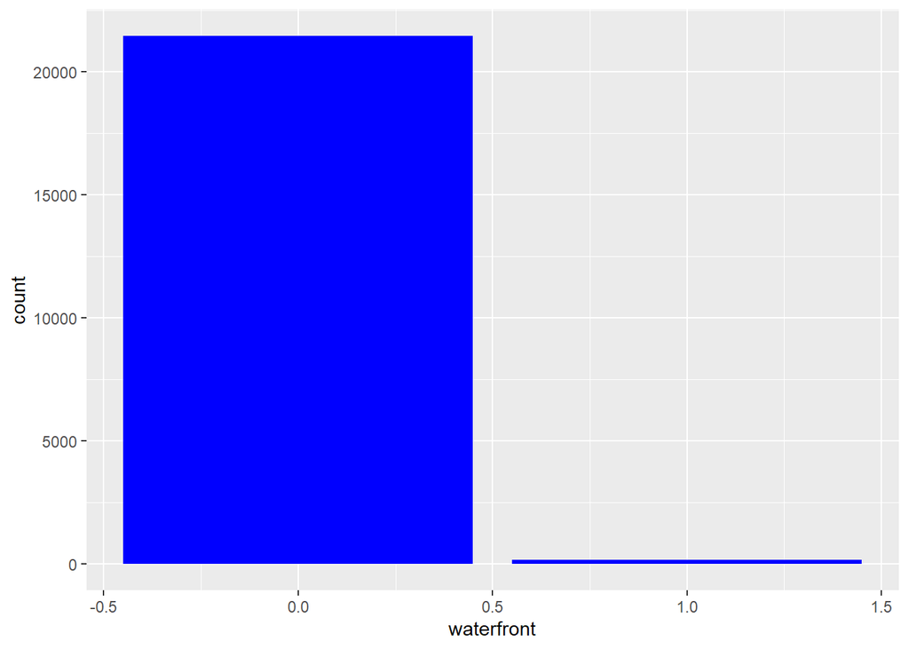

```r
watrfrnt <- ggplot(data = houses, mapping = aes(waterfront))
view_grade <- ggplot(data = houses, mapping = aes(view))
build_qaulity <- ggplot(data = houses, mapping = aes(grade))
current_cond <- ggplot(data = houses, mapping = aes(condition))
year_built <- ggplot(data = houses, mapping = aes(yr_built))
yr_reno <- ggplot(data = houses, mapping = aes(yr_renovated))
zip_code <- ggplot(data = houses, mapping = aes(zip_code))

watrfrnt + geom_bar(fill = "blue")
```

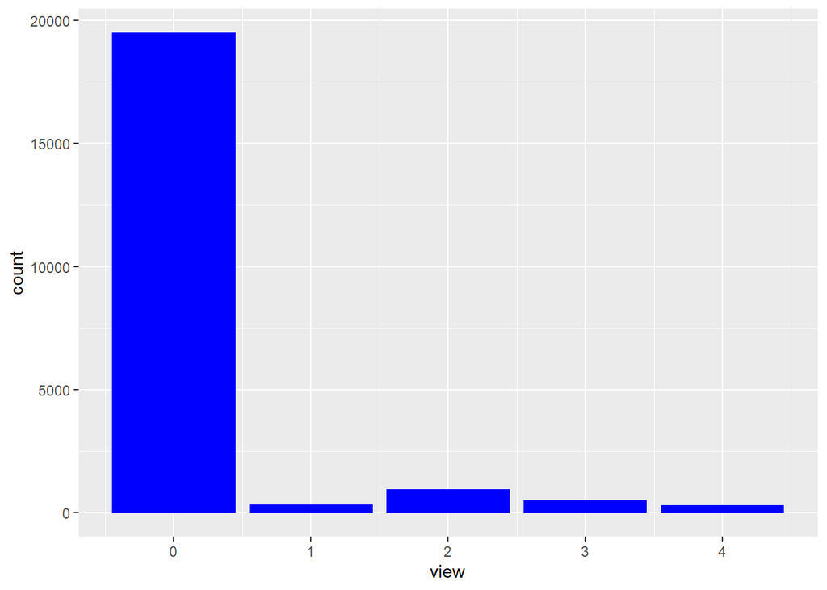

```r
view_grade + geom_bar(fill = "blue")
```

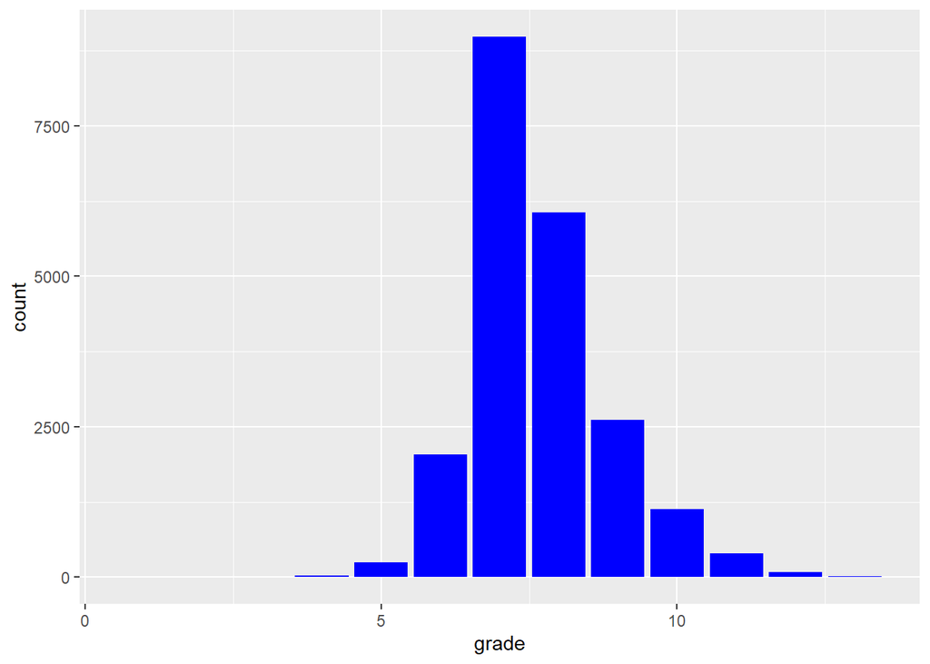

```r
build_qaulity + geom_bar(fill = "blue")
```

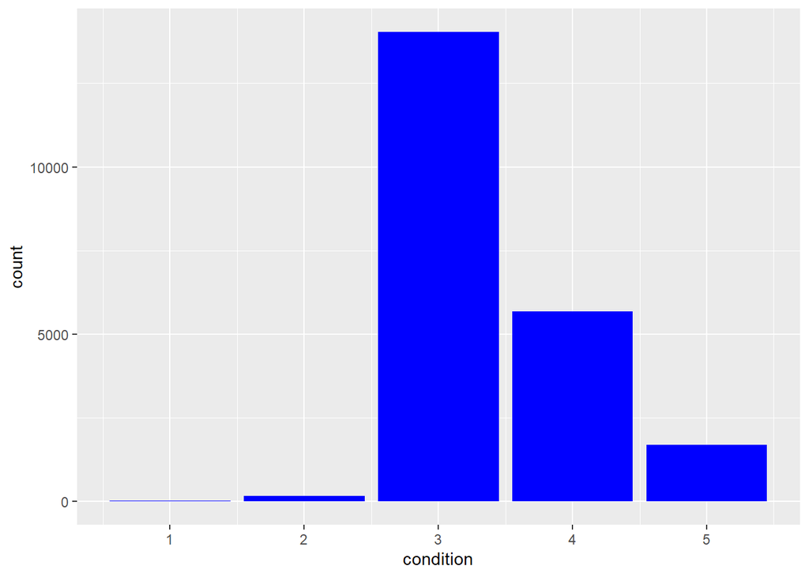

```r
current_cond + geom_bar(fill = "blue")
```

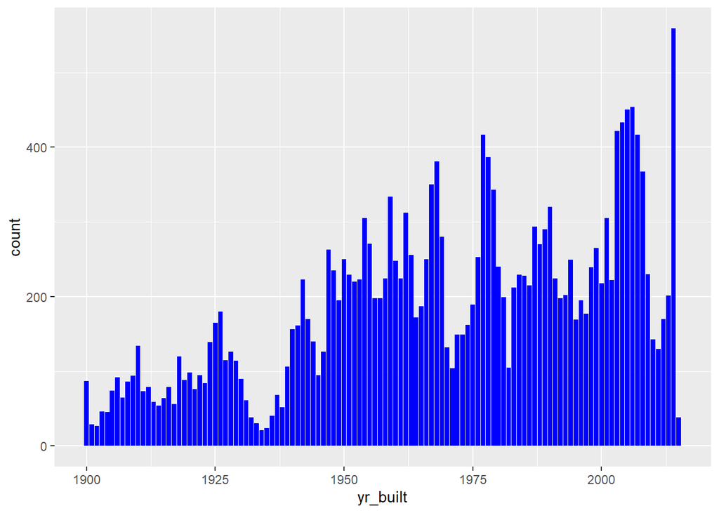

```r
year_built + geom_bar(fill = "blue")
```

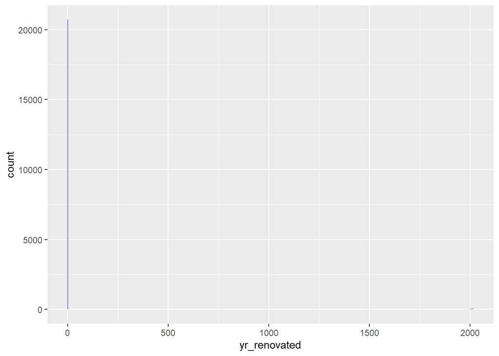

```r
yr_reno + geom_bar(fill = "blue", binwidth = 1000)
```

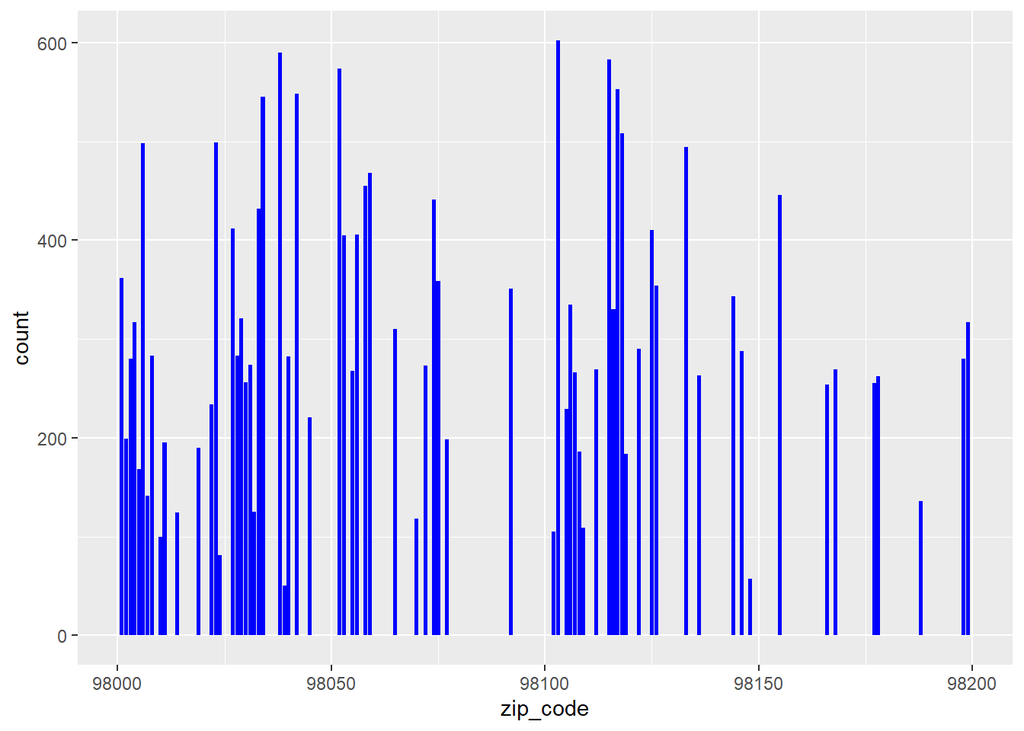

```r
zip_code + geom_bar(fill = "blue")
```

**Comments**

- The majority of homes do not have a water front view
  - it appears we may have a lot of inner city rural homes in this data
- Most homes are in moderate condition with a rating of 3
  - Many are in reasonable condition, and were built at a moderate grade
- The majority of the homes have never been renovated
  - renovations are mostly nonexistant, just general maintenance performed.

## 4.2 Quantitative variables

### 4.2.1 Price

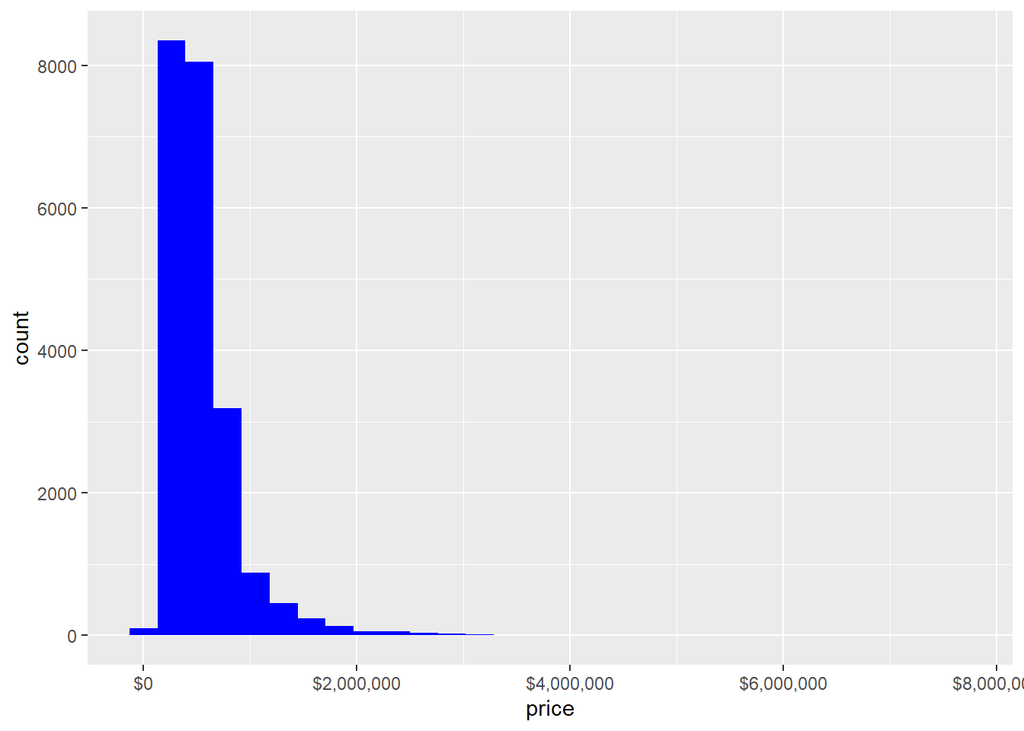

```r
price <- ggplot(data = houses, mapping = aes(price))
price + geom_histogram(fill = "blue") + scale_x_continuous(labels = scales :: dollar)
```

### 4.2.2 Bedrooms

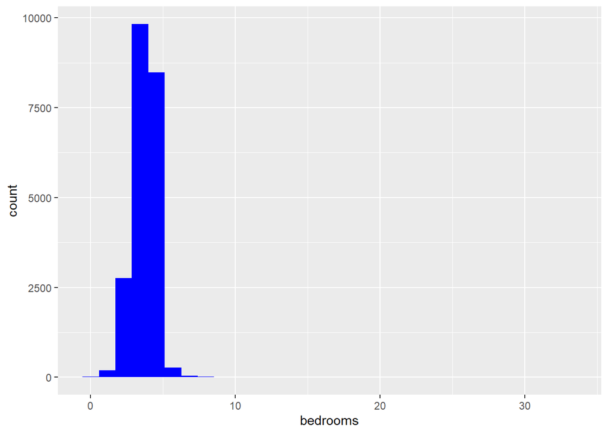

```r
bedrooms <- ggplot(data = houses, mapping = aes(bedrooms))
bedrooms + geom_histogram(fill = "blue")
```

### 4.2.3 Bathrooms

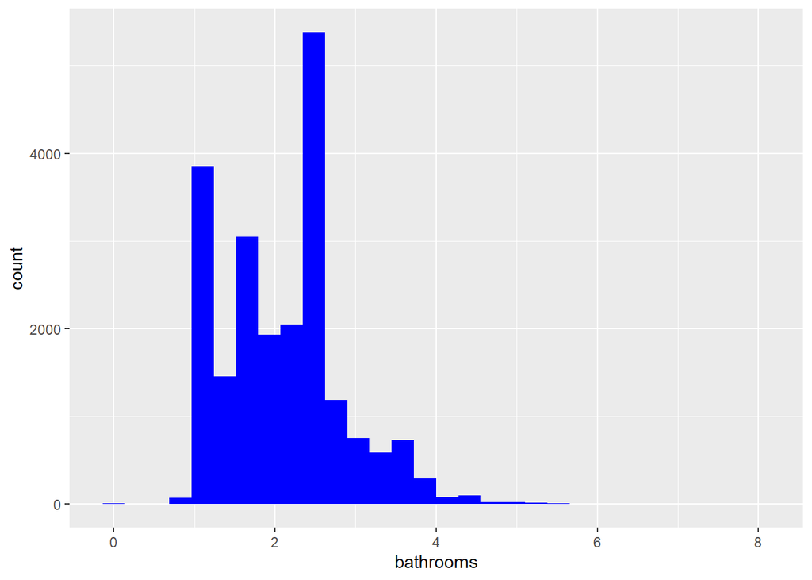

```r
bathrooms <- ggplot(data = houses, mapping = aes(bathrooms))
bathrooms + geom_histogram(fill = "blue")
```

### 4.2.4 Square Feet of living space

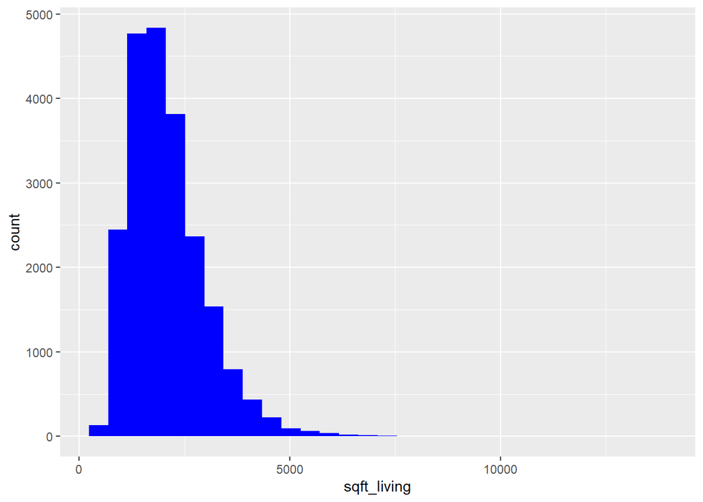

```r
sqft_living <- ggplot(data = houses, mapping = aes(sqft_living))
sqft_living + geom_histogram(fill = "blue")
```

### 4.2.5 Size of Lot

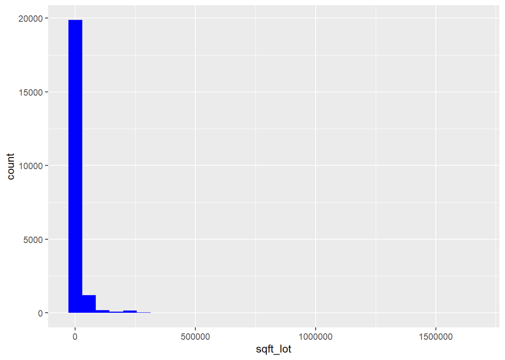

```r
sqft_lot <- ggplot(data = houses, mapping = aes(sqft_lot))
sqft_lot + geom_histogram(fill = "blue")
```

### 4.2.6 Number of Stories

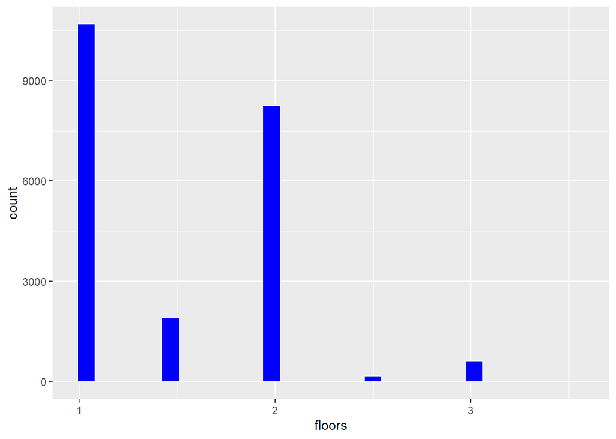

```r
levels <- ggplot(data = houses, mapping = aes(floors))
levels + geom_histogram(fill = "blue")
```

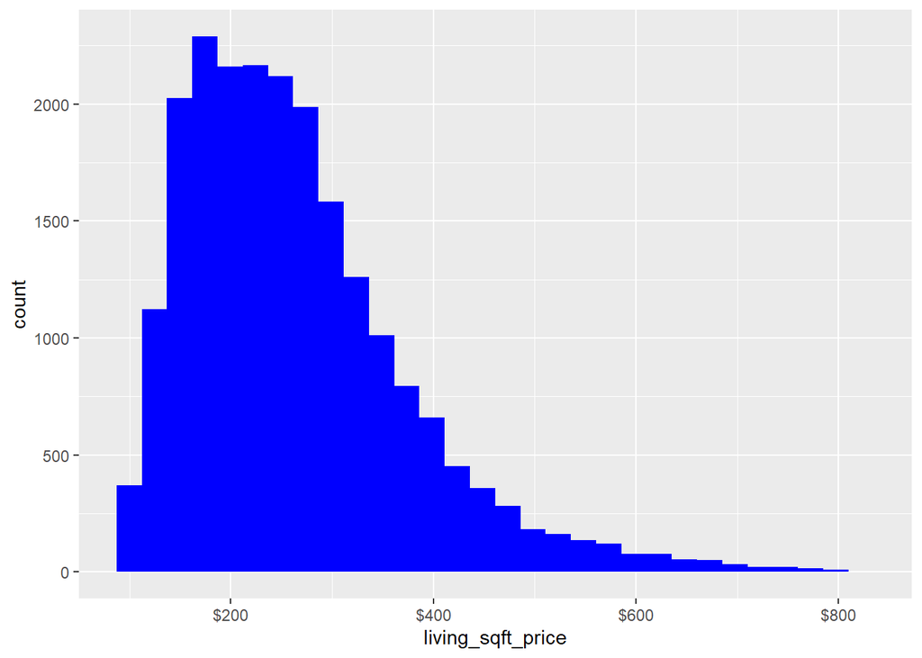

```r
per_sqft_living <- ggplot(data = houses, mapping = aes(living_sqft_price))
per_sqft_living + geom_histogram(fill = "blue") +
  scale_x_continuous(labels = scales :: dollar)
```

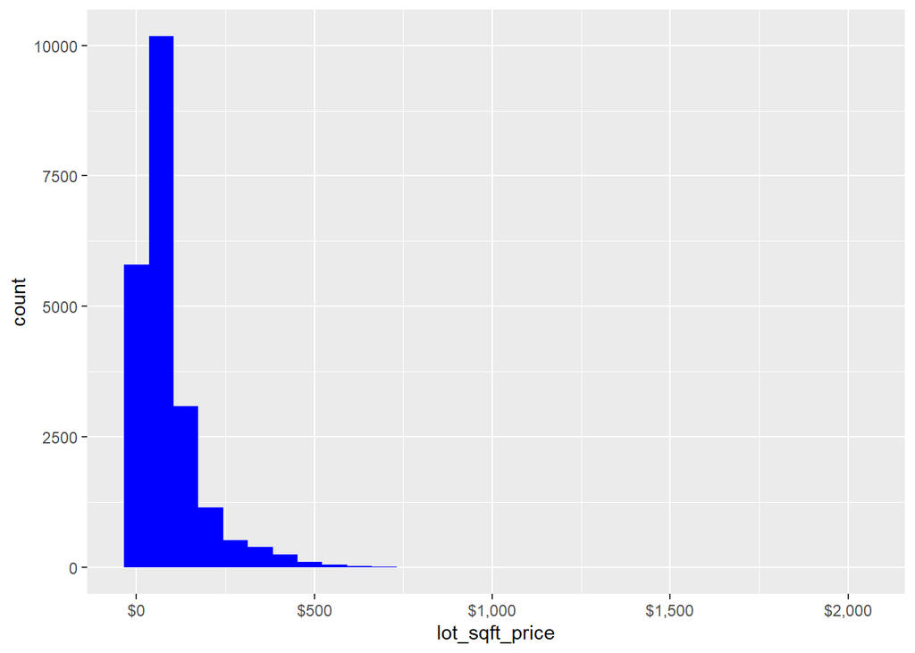

```r
per_sqft_lot <- ggplot(data = houses, mapping = aes(lot_sqft_price))
per_sqft_lot + geom_histogram(fill = "blue") +
  scale_x_continuous(labels = scales :: dollar)
```

+ Portrays the variety of skew for each variable + Quantitative variables Price, Bedrooms, and sqft of living all have very harsh fall off, and long tail to right.

```
- will use median rather than mean for analysis
- This portrays how there are most likely some "mansions" in the data set causing skew.
- but they are important to our research question so will not remove them at this point.
- It would be a good idea to take the top 10% and bottom 10% of observations off to check at some point
```

- Bathrooms is the variable that seems the most normally distributed
  - Even here though there is the oddity of bathrooms being counted as a fraction of a unit.
- The Mutated variables I added on are also skewed with long tails to the right.
  - This makes sense as houses with extrodinarily high price per sqft of living and of the lot are uncommon.

### 4.2.7 Full Categorical

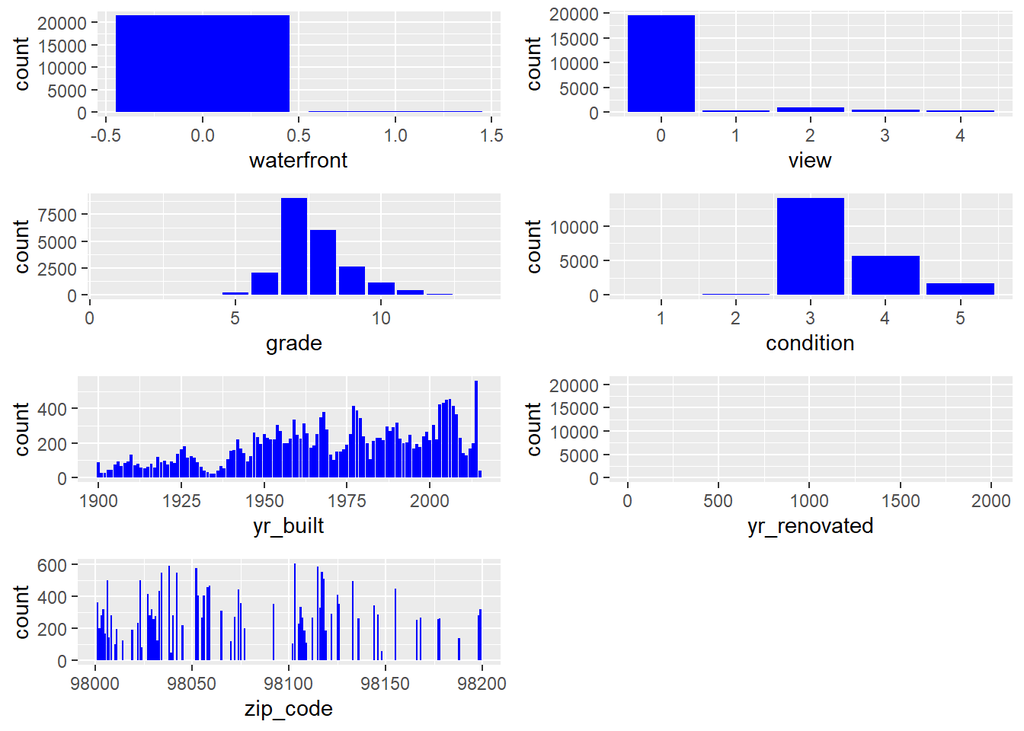

### 4.2.8 Full Quantitative

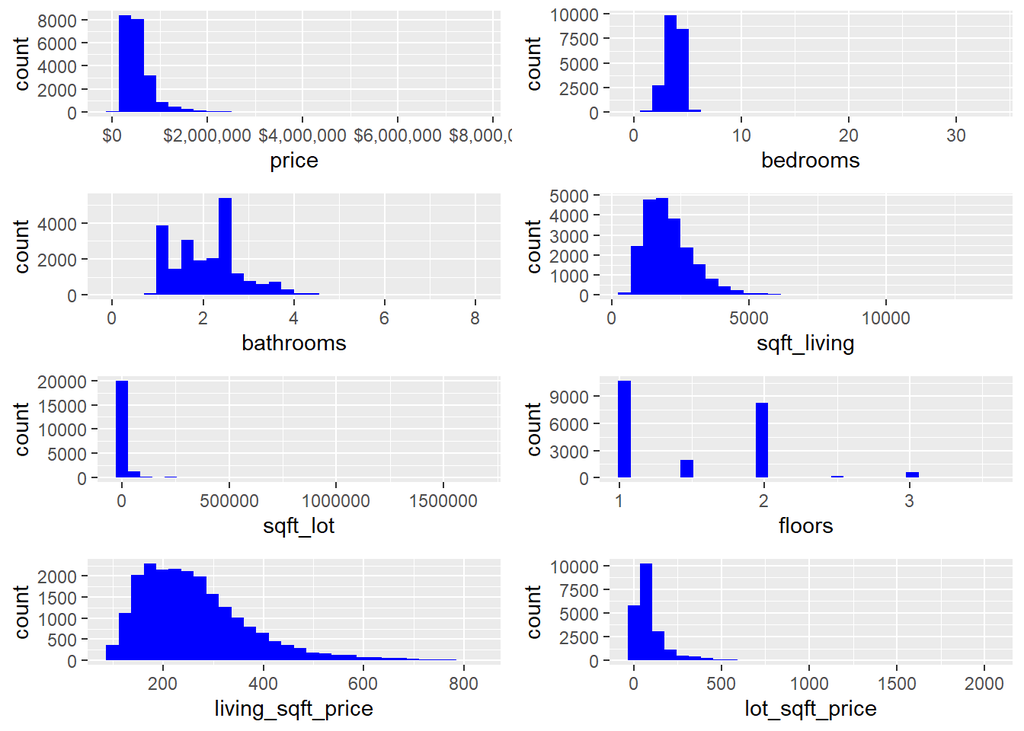

# 5 Base EDA Step 3: Multi-variate non-graphical

## 5.1 Categorical

### 5.1.1 Grade and view

```r
# Countingency/cross table
houses %>%
  tabyl(grade, view) %>% # creates table of counts
  adorn_totals(where = c("row", "col")) # Total margins
```

```
##  grade     0   1   2   3   4 Total
##      1     1   0   0   0   0     1
##      3     3   0   0   0   0     3
##      4    26   2   1   0   0    29
##      5   229   2   6   1   4   242
##      6  1955  15  42  14  12  2038
##      7  8556  94 222  78  31  8981
##      8  5412 110 326 146  74  6068
##      9  2160  63 189 130  73  2615
##     10   857  26 102  84  65  1134
##     11   242  18  59  45  35   399
##     12    43   2  13  10  22    90
##     13     5   0   3   2   3    13
##  Total 19489 332 963 510 319 21613
```

```r
# Proportion contingency/cross table
houses %>%
  tabyl(grade, view) %>% # creates table of counts
  adorn_totals(where = c("row", "col")) %>%  # Total margins
  adorn_percentages(denominator = "all") %>% # creates proportions
  adorn_rounding(2) # round decimals
```

```
##  grade    0    1    2    3    4 Total
##      1 0.00 0.00 0.00 0.00 0.00  0.00
##      3 0.00 0.00 0.00 0.00 0.00  0.00
##      4 0.00 0.00 0.00 0.00 0.00  0.00
##      5 0.01 0.00 0.00 0.00 0.00  0.01
##      6 0.09 0.00 0.00 0.00 0.00  0.09
##      7 0.40 0.00 0.01 0.00 0.00  0.42
##      8 0.25 0.01 0.02 0.01 0.00  0.28
##      9 0.10 0.00 0.01 0.01 0.00  0.12
##     10 0.04 0.00 0.00 0.00 0.00  0.05
##     11 0.01 0.00 0.00 0.00 0.00  0.02
##     12 0.00 0.00 0.00 0.00 0.00  0.00
##     13 0.00 0.00 0.00 0.00 0.00  0.00
##  Total 0.90 0.02 0.04 0.02 0.01  1.00
```

### 5.1.2 Grade and Condition

```r
# Proportion contingency/cross table
houses %>%
  tabyl(grade, condition) %>% # creates table of counts
  adorn_totals(where = c("row", "col"))
```

```
##  grade  1   2     3    4    5 Total
##      1  1   0     0    0    0     1
##      3  0   1     1    0    1     3
##      4  1   5    13   10    0    29
##      5  9  15   100   84   34   242
##      6 11  59  1035  685  248  2038
##      7  6  75  5234 2833  833  8981
##      8  2  13  4269 1394  390  6068
##      9  0   2  2041  446  126  2615
##     10  0   2   921  156   55  1134
##     11  0   0   332   56   11   399
##     12  0   0    74   13    3    90
##     13  0   0    11    2    0    13
##  Total 30 172 14031 5679 1701 21613
```

```r
# Proportion contingency/cross table
houses %>%
  tabyl(grade, condition) %>% # creates table of counts
  adorn_totals(where = c("row", "col")) %>%  # Total margins
  adorn_percentages(denominator = "all") %>% # creates proportions
  adorn_rounding(2) # round decimals
```

```
##  grade 1    2    3    4    5 Total
##      1 0 0.00 0.00 0.00 0.00  0.00
##      3 0 0.00 0.00 0.00 0.00  0.00
##      4 0 0.00 0.00 0.00 0.00  0.00
##      5 0 0.00 0.00 0.00 0.00  0.01
##      6 0 0.00 0.05 0.03 0.01  0.09
##      7 0 0.00 0.24 0.13 0.04  0.42
##      8 0 0.00 0.20 0.06 0.02  0.28
##      9 0 0.00 0.09 0.02 0.01  0.12
##     10 0 0.00 0.04 0.01 0.00  0.05
##     11 0 0.00 0.02 0.00 0.00  0.02
##     12 0 0.00 0.00 0.00 0.00  0.00
##     13 0 0.00 0.00 0.00 0.00  0.00
##  Total 0 0.01 0.65 0.26 0.08  1.00
```

### 5.1.3 Zip code and Year Renovated

```r
# Proportion contingency/cross table
houses %>%
  tabyl(zip_code, yr_renovated) %>% # creates table of counts
  adorn_totals(where = c("row", "col"))
```

```
##  zip_code     0 1934 1940 1944 1945 1946 1948 1950 1951 1953 1954 1955 1956
##     98001   354    0    0    0    0    0    0    0    0    0    0    0    0
##     98002   193    0    0    0    0    0    0    0    0    0    0    0    0
##     98003   277    0    0    0    0    0    0    0    0    0    0    0    0
##     98004   284    0    0    0    0    0    0    0    0    0    0    0    0
##     98005   164    0    0    0    0    0    0    0    0    0    0    0    0
##     98006   478    0    0    0    0    0    0    0    0    0    0    0    0
##     98007   137    0    0    0    0    0    0    0    0    0    0    0    0
##     98008   276    0    0    0    0    0    0    0    0    0    0    0    0
##     98010    89    0    0    0    0    0    0    0    0    0    0    0    0
##     98011   190    0    0    0    1    0    0    0    0    0    0    0    0
##     98014   121    0    0    0    0    0    0    0    0    0    0    0    0
##     98019   184    0    0    0    0    0    0    0    0    0    0    0    0
##     98022   219    0    0    0    0    0    0    1    0    0    0    0    0
##     98023   492    0    0    0    0    0    0    0    0    0    0    0    0
```

[output cut: 345 more lines]

```r
# Proportion contingency/cross table
houses %>%
  tabyl(zip_code, yr_renovated) %>% # creates table of counts
  adorn_totals(where = c("row", "col")) %>%  # Total margins
  adorn_percentages(denominator = "all") %>% # creates proportions
  adorn_rounding(2) # round decimals
```

```
##  zip_code    0 1934 1940 1944 1945 1946 1948 1950 1951 1953 1954 1955 1956 1957
##     98001 0.02    0    0    0    0    0    0    0    0    0    0    0    0    0
##     98002 0.01    0    0    0    0    0    0    0    0    0    0    0    0    0
##     98003 0.01    0    0    0    0    0    0    0    0    0    0    0    0    0
##     98004 0.01    0    0    0    0    0    0    0    0    0    0    0    0    0
##     98005 0.01    0    0    0    0    0    0    0    0    0    0    0    0    0
##     98006 0.02    0    0    0    0    0    0    0    0    0    0    0    0    0
##     98007 0.01    0    0    0    0    0    0    0    0    0    0    0    0    0
##     98008 0.01    0    0    0    0    0    0    0    0    0    0    0    0    0
##     98010 0.00    0    0    0    0    0    0    0    0    0    0    0    0    0
##     98011 0.01    0    0    0    0    0    0    0    0    0    0    0    0    0
##     98014 0.01    0    0    0    0    0    0    0    0    0    0    0    0    0
##     98019 0.01    0    0    0    0    0    0    0    0    0    0    0    0    0
##     98022 0.01    0    0    0    0    0    0    0    0    0    0    0    0    0
##     98023 0.02    0    0    0    0    0    0    0    0    0    0    0    0    0
```

[output cut: 345 more lines]

### 5.1.4 Year Built and Current Condition

```r
# Proportion contingency/cross table
houses %>%
  tabyl(yr_built, condition) %>% # creates table of counts
  adorn_totals(where = c("row", "col"))
```

```
##  yr_built  1   2     3    4    5 Total
##      1900  2   2    44   26   13    87
##      1901  1   0    13    9    6    29
##      1902  0   0    15    7    5    27
##      1903  0   1    28   10    7    46
##      1904  0   0    21   12   12    45
##      1905  0   1    38   12   23    74
##      1906  0   6    34   36   16    92
##      1907  0   0    33   21   11    65
##      1908  1   1    35   29   20    86
##      1909  0   0    36   38   20    94
##      1910  2   1    60   43   28   134
##      1911  0   1    33   18   21    73
##      1912  0   2    34   27   16    79
##      1913  0   1    26   23    9    59
```

[output cut: 103 more lines]

```r
# Proportion contingency/cross table
houses %>%
  tabyl(yr_built, condition) %>% # creates table of counts
  adorn_totals(where = c("row", "col")) %>%  # Total margins
  adorn_percentages(denominator = "all") %>% # creates proportions
  adorn_rounding(2) # round decimals
```

```
##  yr_built 1    2    3    4    5 Total
##      1900 0 0.00 0.00 0.00 0.00  0.00
##      1901 0 0.00 0.00 0.00 0.00  0.00
##      1902 0 0.00 0.00 0.00 0.00  0.00
##      1903 0 0.00 0.00 0.00 0.00  0.00
##      1904 0 0.00 0.00 0.00 0.00  0.00
##      1905 0 0.00 0.00 0.00 0.00  0.00
##      1906 0 0.00 0.00 0.00 0.00  0.00
##      1907 0 0.00 0.00 0.00 0.00  0.00
##      1908 0 0.00 0.00 0.00 0.00  0.00
##      1909 0 0.00 0.00 0.00 0.00  0.00
##      1910 0 0.00 0.00 0.00 0.00  0.01
##      1911 0 0.00 0.00 0.00 0.00  0.00
##      1912 0 0.00 0.00 0.00 0.00  0.00
##      1913 0 0.00 0.00 0.00 0.00  0.00
```

[output cut: 103 more lines]

**Comments**

**Questions**

- Need to check one overlap of condition, grade and price
- should we remove renovate since it is so unuseful?

## 5.2 Quantitative

```r
#uses all my variables? SHould I code it to be just the first 6?
houses %>%
  select_if(is.numeric) %>% # Use to select just the numeric variables
  cor() %>%
  round(2) %>%
  kable()
```

|  | price | bedrooms | bathrooms | sqft_living | sqft_lot | floors | waterfront | view | grade | condition | yr_built | yr_renovated | zip_code | living_sqft_price | lot_sqft_price |
| --- | --- | --- | --- | --- | --- | --- | --- | --- | --- | --- | --- | --- | --- | --- | --- |
| price | 1.00 | 0.31 | 0.53 | 0.70 | 0.09 | 0.26 | 0.27 | 0.40 | 0.67 | 0.04 | 0.05 | 0.13 | -0.05 | 0.56 | 0.31 |
| bedrooms | 0.31 | 1.00 | 0.52 | 0.58 | 0.03 | 0.18 | -0.01 | 0.08 | 0.36 | 0.03 | 0.15 | 0.02 | -0.15 | -0.21 | -0.06 |
| bathrooms | 0.53 | 0.52 | 1.00 | 0.75 | 0.09 | 0.50 | 0.06 | 0.19 | 0.66 | -0.12 | 0.51 | 0.05 | -0.20 | -0.09 | 0.20 |
| sqft_living | 0.70 | 0.58 | 0.75 | 1.00 | 0.17 | 0.35 | 0.10 | 0.28 | 0.76 | -0.06 | 0.32 | 0.06 | -0.20 | -0.09 | 0.02 |
| sqft_lot | 0.09 | 0.03 | 0.09 | 0.17 | 1.00 | -0.01 | 0.02 | 0.07 | 0.11 | -0.01 | 0.05 | 0.01 | -0.13 | -0.03 | -0.21 |
| floors | 0.26 | 0.18 | 0.50 | 0.35 | -0.01 | 1.00 | 0.02 | 0.03 | 0.46 | -0.26 | 0.49 | 0.01 | -0.06 | 0.00 | 0.48 |
| waterfront | 0.27 | -0.01 | 0.06 | 0.10 | 0.02 | 0.02 | 1.00 | 0.40 | 0.08 | 0.02 | -0.03 | 0.09 | 0.03 | 0.19 | 0.03 |
| view | 0.40 | 0.08 | 0.19 | 0.28 | 0.07 | 0.03 | 0.40 | 1.00 | 0.25 | 0.05 | -0.05 | 0.10 | 0.08 | 0.22 | 0.08 |
| grade | 0.67 | 0.36 | 0.66 | 0.76 | 0.11 | 0.46 | 0.08 | 0.25 | 1.00 | -0.14 | 0.45 | 0.01 | -0.18 | 0.12 | 0.22 |
| condition | 0.04 | 0.03 | -0.12 | -0.06 | -0.01 | -0.26 | 0.02 | 0.05 | -0.14 | 1.00 | -0.36 | -0.06 | 0.00 | 0.10 | -0.09 |
| yr_built | 0.05 | 0.15 | 0.51 | 0.32 | 0.05 | 0.49 | -0.03 | -0.05 | 0.45 | -0.36 | 1.00 | -0.22 | -0.35 | -0.29 | 0.12 |
| yr_renovated | 0.13 | 0.02 | 0.05 | 0.06 | 0.01 | 0.01 | 0.09 | 0.10 | 0.01 | -0.06 | -0.22 | 1.00 | 0.06 | 0.11 | 0.04 |
| zip_code | -0.05 | -0.15 | -0.20 | -0.20 | -0.13 | -0.06 | 0.03 | 0.08 | -0.18 | 0.00 | -0.35 | 0.06 | 1.00 | 0.17 | 0.22 |
| living_sqft_price | 0.56 | -0.21 | -0.09 | -0.09 | -0.03 | 0.00 | 0.19 | 0.22 | 0.12 | 0.10 | -0.29 | 0.11 | 0.17 | 1.00 | 0.45 |
| lot_sqft_price | 0.31 | -0.06 | 0.20 | 0.02 | -0.21 | 0.48 | 0.03 | 0.08 | 0.22 | -0.09 | 0.12 | 0.04 | 0.22 | 0.45 | 1.00 |

**Comments**

- Strong correlation between price and sqft_living, as well as the initial grade of the build
  - This makes good sense, but it is interesting that it appears that current condition has little to do with price.
  - Also interesting that price doesn’t seem to correlate with size of the lot or the year it was built
- Not surprising That something like zipcode has little to no correlation on any of the variables.
- There are no strong correlations for the price per foot calculations for lot and living space .
  - I would interpret this as there being no single variable that makes an amount of space worth something. -Each variable of the condition, grade, view and location all impact the price.

**Questions**

- Does positive correlation imply causation: The higher the price, the larger the house?
  - Makes sense since the larger the home, the more materials needed.

# 6 Base EDA Step 4: Multi-variate graphical

## 6.1 Step 4.1: Categorical

- Bar graphs with multiple categorical variables

```r
condition <- factor("condition", levels = 1:5)
class(condition)#should have fixed the problem but it
```

```
## [1] "factor"
```

```r
condition
```

```
## [1] <NA>
## Levels: 1 2 3 4 5
```

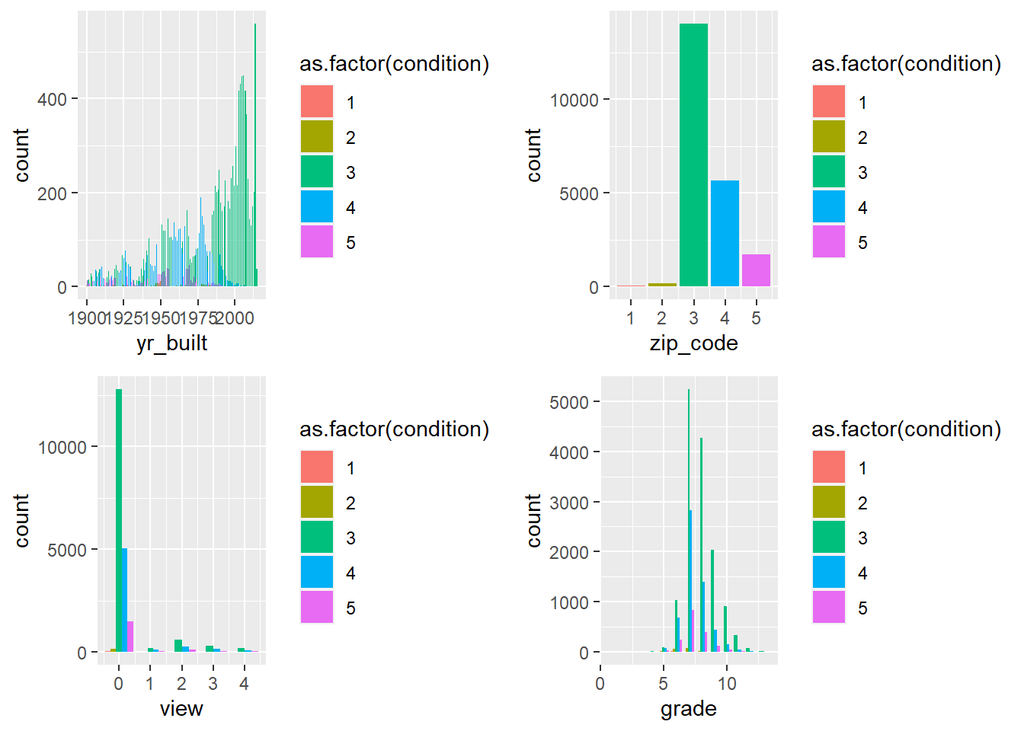

```r
grid.arrange(
  houses %>%
    ggplot(mapping = aes(x = yr_built, fill = as.factor(condition))) +
    geom_bar(position = "dodge"),

  houses %>%
    ggplot(mapping = aes(x = zip_code, fill = as.factor(condition))) +
    geom_bar(position = "dodge", mapping = aes(condition)),

  houses %>%
    ggplot(mapping = aes(x = view, fill = as.factor(condition))) +
    geom_bar(position = "dodge"),

  houses %>%
    ggplot(mapping = aes(x = grade)) +
    geom_bar(position = "dodge", mapping = aes(fill = as.factor(condition))),

  ncol = 2)
```

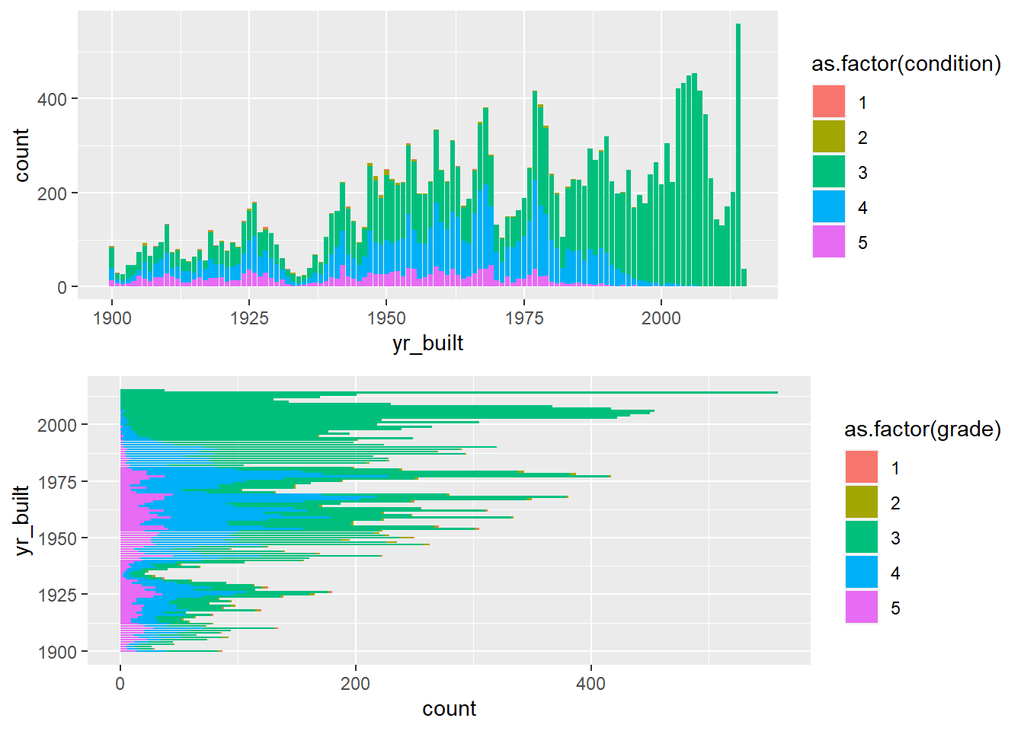

```r
grid.arrange(
  # Cluster of counts
  houses %>%
    ggplot(mapping = aes(x = yr_built)) + # Add additional variable by specify "fill"
      geom_bar(mapping= aes(fill = as.factor(condition))),
  # Proportion of counts
  houses %>%
    group_by(yr_built, grade) %>%
    ggplot(mapping = aes(x = yr_built, fill = as.factor(grade))) + # Add additional variable by specify "fill"
      geom_bar(mapping = aes(fill = as.factor(condition))) +
      coord_flip(),

ncol = 1
)
```

**Comments**

- We have good spread of data on building years.
  - unusually low in the 2008 time period, maybe because of housing crash
  - We have more data on homes built more recently
  - The concentration of quality is spread out of the years.
  - older homes have more of a chance of decaying quality
  - more mid range quality homes built recently

**Questions**

- How does price vary per year on the homes?
- Do only old homes degrade?

## 6.2 Step 4.2: Quantitative

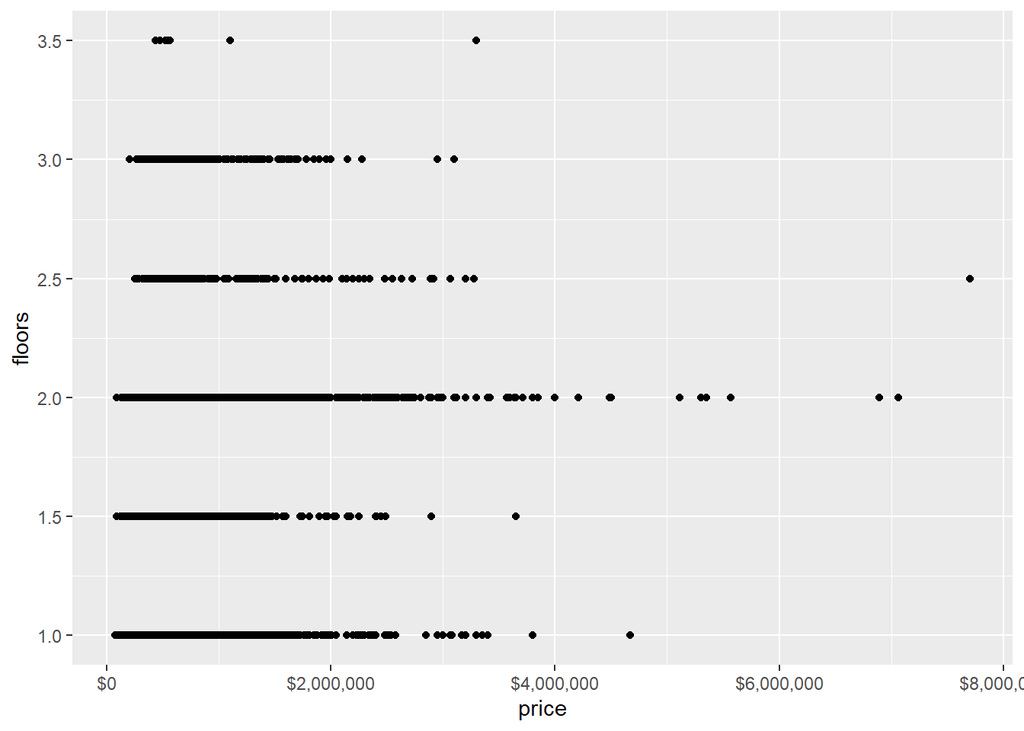

```r
# Code scatterplots using grid.arrange so can see all quant variables of interest together
houses %>%
  ggplot(mapping = aes(x = price, y = floors)) +
  geom_point() + scale_x_continuous(labels = scales :: dollar)
```

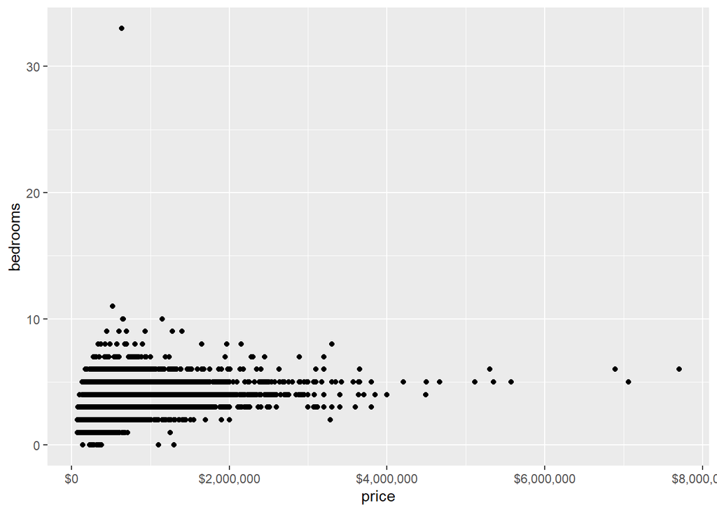

```r
# Code scatterplots using grid.arrange so can see all quant variables of interest together
houses %>%
  ggplot(mapping = aes(x = price, y = bedrooms)) +
  geom_point() + scale_x_continuous(labels = scales :: dollar)
```

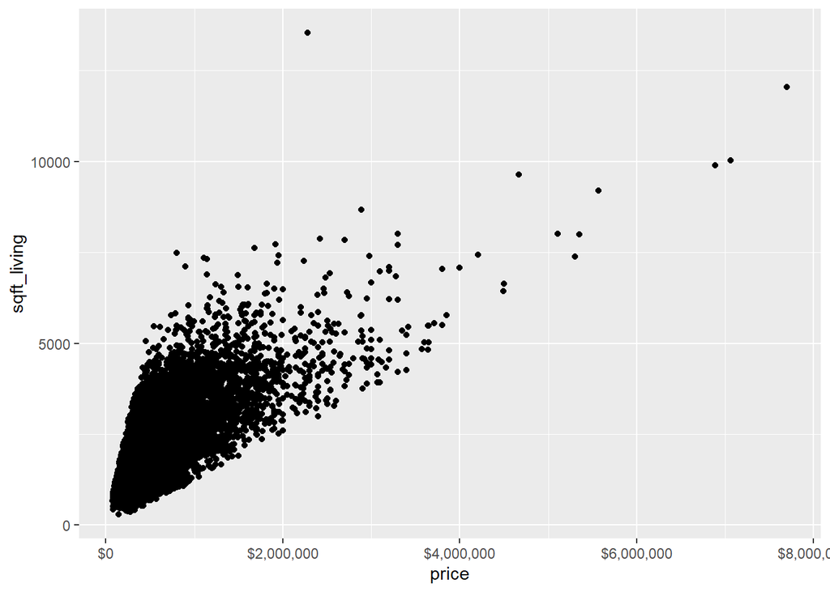

```r
# Code scatterplots using grid.arrange so can see all quant variables of interest together
houses %>%
  ggplot(mapping = aes(x = price, y = sqft_living)) +
  geom_point() + scale_x_continuous(labels = scales :: dollar)
```

**Comments**

- Interesting pattern
  - Bedrooms, space and floors usually all impact price
  - however there are multi floor houses with rooms that are cheaper then they should be
  - This could be due to quality and condition of the home

**Questions**

- How do grade, condition and size interact to cause this disparity?
  - observe median price per square foot in comparison with build details

## 6.3 Step 4.3: Categorical and quantitative

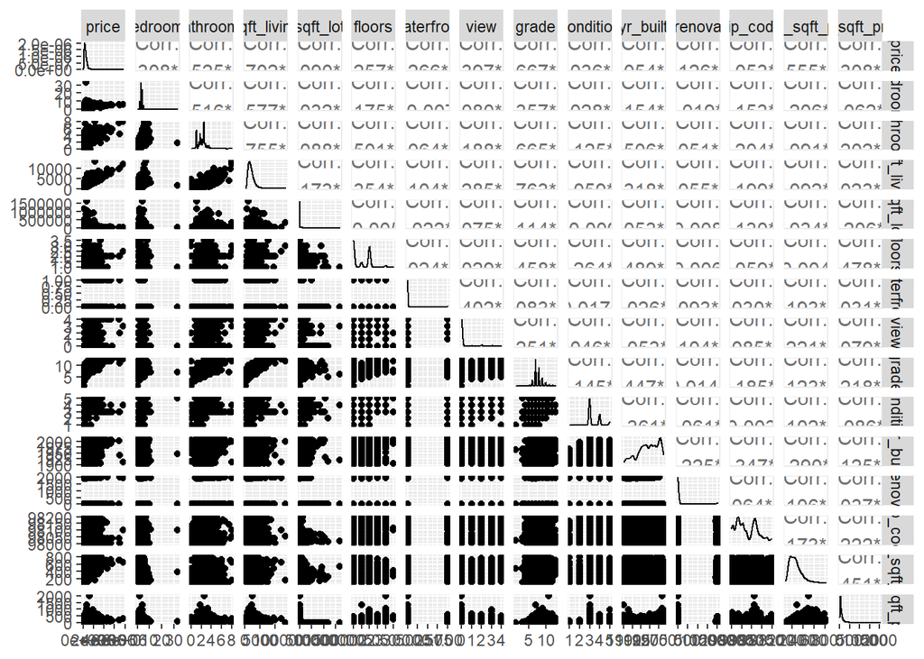

```r
# Use ggpairs from the GGally package
houses %>%
  ggpairs()
```

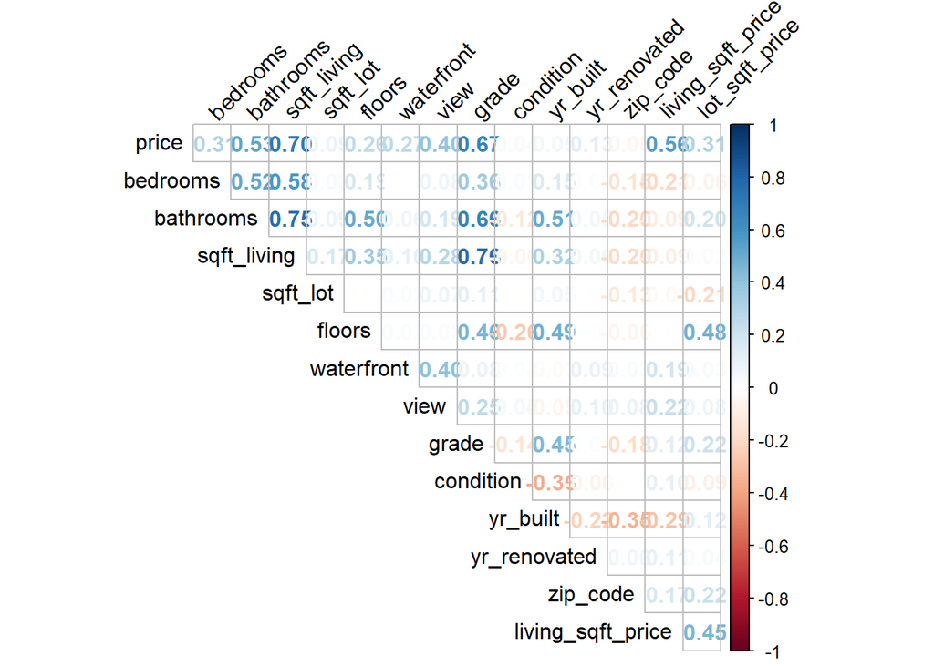

```r
cor_houses<- (cor(houses))
corrplot(cor_houses,
         method = "number",
         sig.level = 0.05,
         order = "original",
         diag = FALSE,
         type = "upper",
         tl.srt = 45,
         tl.col = "black")
```

**Comments**

- Each factor contributes reasonably
  - both grade and size of the house impact the price -grade and condition are intertwine slightly
  - the size of the living space impacts initial grade
    - nice large homes

**Questions**

- Look more closely at:
  - location, condition, grade, price, size
  - size and price together

## 6.4 Location, price and quality

**Follow up on correlation graph questions below**

```r
# Show code
houses <- read.csv("qp1_data.csv")
#head(houses, 10)
str("condition")
```

```
##  chr "condition"
```

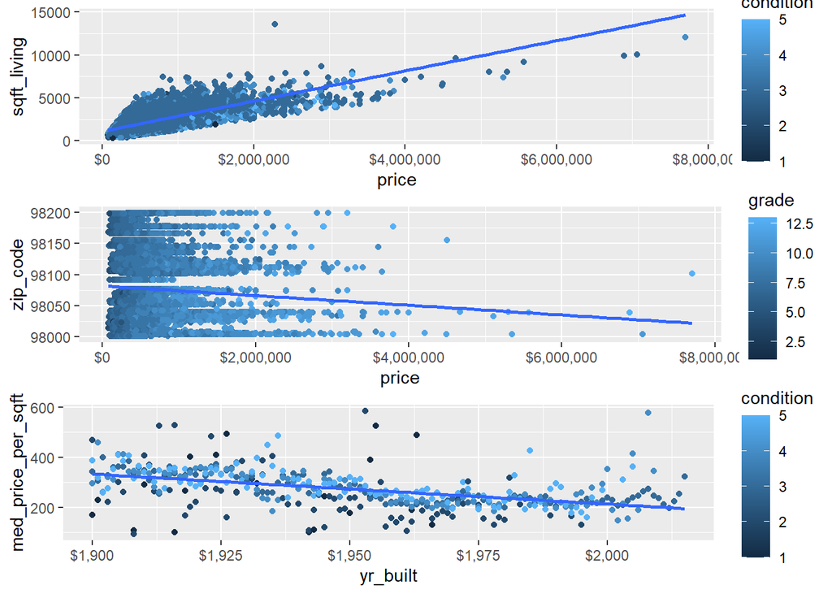

```r
grid.arrange(
  # age, price size and condition
  houses %>%
    ggplot(mapping = aes(x = price, y = sqft_living, color = condition)) +
      geom_point() +
      geom_smooth(method = "lm", se = FALSE) +
    scale_x_continuous(labels = scales :: dollar),

    houses %>%
    ggplot(mapping = aes(x = price, y = zip_code, color = grade)) +
      geom_point() +
      geom_smooth(method = "lm", se = FALSE) +
    scale_x_continuous(labels = scales :: dollar),

    houses %>%
      mutate(living_sqft_price = price/sqft_living) %>%
      group_by(yr_built, condition) %>%
      summarise(med_price_per_sqft= median(living_sqft_price)) %>%
        ggplot(mapping = aes(x = yr_built, y = med_price_per_sqft, color = condition)) +
          geom_point() +
          geom_smooth(method = "lm", se = FALSE) +
          scale_x_continuous(labels = scales :: dollar),

ncol = 1
)
```

**Comments**

- The shading outliers for grade and condition are similar
  - it appears that both grade and condition have outliers that impact price
  - there is a steady shading pattern left to right for grade, but it is staggered for condition
- Zip codes do appear to impact price
  - there are som zipcodes that have only low price homes, and some with high price -the slop of the regression line is weak and insignificant for zip code

**Questions**

- Look at zip code impact on quality and condition
  - is condition and grade spread evenly between zip codes?

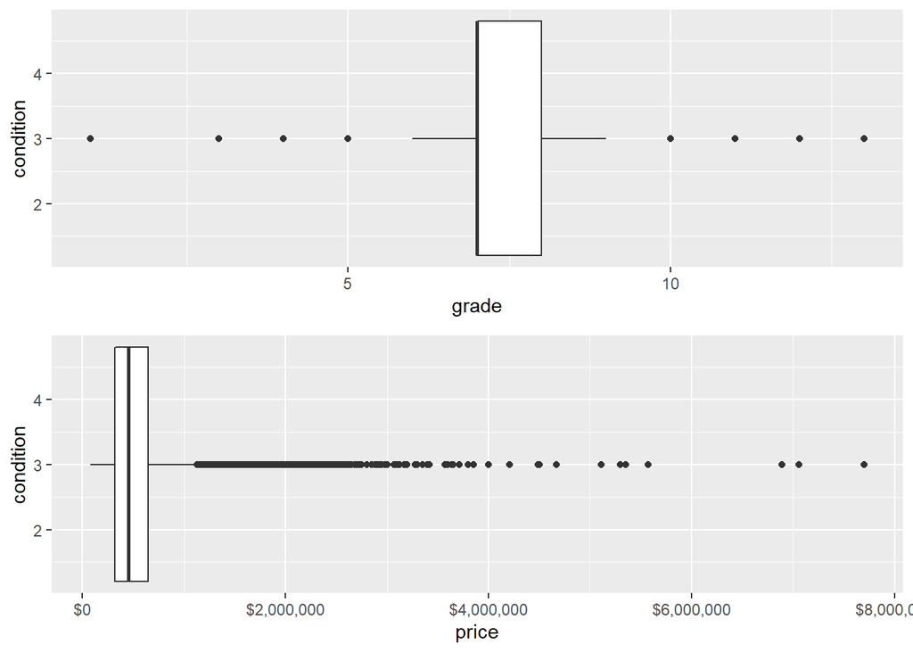

```r
# Show code
grid.arrange(
  # condition and grade
  houses %>%
    ggplot(mapping = aes(x = condition, y = grade)) +
      geom_boxplot() +
    coord_flip(),
  # price and condition
  houses %>%
    ggplot(mapping = aes(x = condition, y = price)) +
      geom_boxplot() +
    coord_flip() +
    scale_y_continuous(labels = scales :: dollar),

ncol = 1
)
```

**Comments**

- Condition Vs. Grade
  - The distribution of grade is very focused between 5-10, with a handful of exceptions on either side
- condition Vs. Price
  - The price is strung out heavily with outliers to the right, and is focused on prices around $300k-$600k

**Questions**

- What impact does condition and grade have
  - are there certain zip codes with low grade, high price?
  - what is more impactful on price, grade or condition?

# 7 Detailed EDA Questions Raised in Base EDA 7

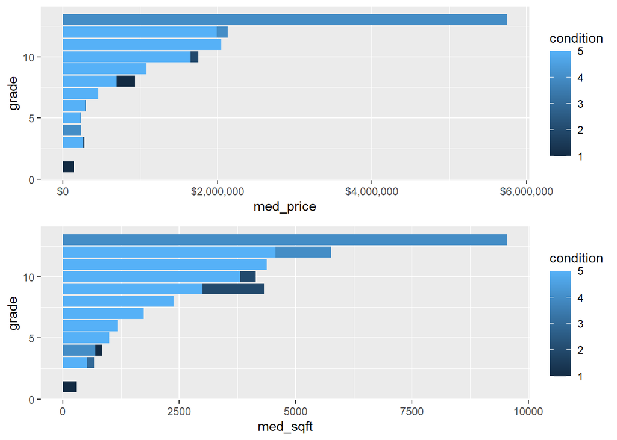

```r
# Group the median expenditure and age in same graph
grid.arrange(

# Median price by condition and grade
houses %>%
  group_by(grade, condition) %>%
  summarise(med_price = median(price)) %>%
  ggplot(mapping = aes(x = grade, y = med_price, fill = condition)) +
    geom_bar(stat = "identity", position = "dodge") +
    coord_flip() +
    scale_y_continuous(labels = scales :: dollar), # Use coord_flip() to make easier to read

# Median year built by condition and grade
houses %>%
  group_by(grade, condition) %>%
  summarise(med_sqft= median(sqft_living)) %>%
  ggplot(mapping = aes(x = grade, y = med_sqft, fill = condition)) +
    geom_bar(stat = "identity", position = "dodge") +
    coord_flip(),

ncol = 1
)
```

**Comments**

- Median Price
  - There are Certainly homes that are very expensive that have declined in quality
  - There are also homes with poor quality that have improved, causing price to rise
  - There are large homes with both varieties of quality

**Questions**

- Curious as to how degraded condition impacts price per foot
  - are there homes that were high quality, and are expensive with low quality condition?
  - how does location play into all of this?

## 7.1 Median price and Quality 7.1

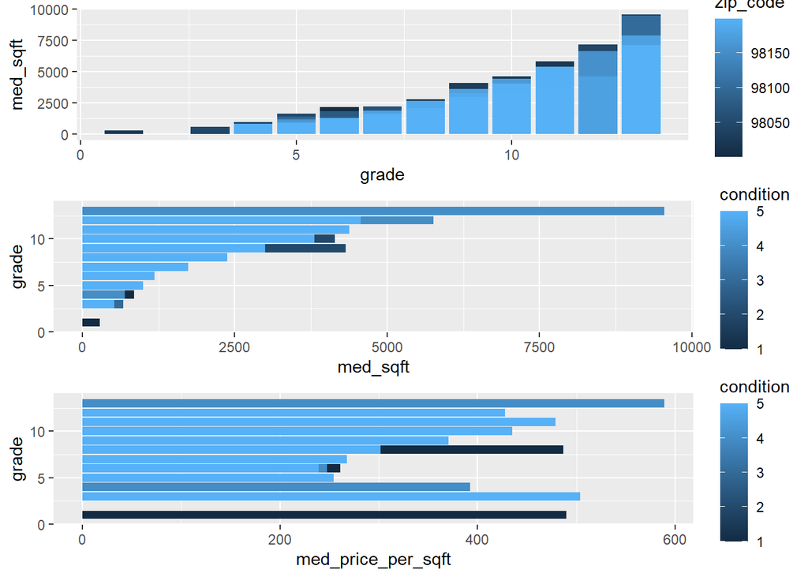

```r
# Group the median expenditure and age in same graph

grid.arrange(

# Median price by condition and grade
houses %>%
  group_by(grade, zip_code) %>%
    summarise(med_sqft = median(sqft_living)) %>%
    ggplot(mapping = aes(x = grade, y = med_sqft, fill = zip_code)) +
      geom_bar(stat = "identity", position = "dodge"),# +
    #coord_flip(), # Use coord_flip() to make easier to read

# Median year built by condition and grade


houses %>%
  group_by(grade, condition) %>%
  summarise(med_sqft= median(sqft_living)) %>%
  ggplot(mapping = aes(x = grade, y = med_sqft, fill = condition)) +
    geom_bar(stat = "identity", position = "dodge") +
    coord_flip(),

houses %>%
  mutate(living_sqft_price = price/sqft_living) %>%
  group_by(grade, condition) %>%
  summarise(med_price_per_sqft= median(living_sqft_price)) %>%
  ggplot(mapping = aes(x = grade, y = med_price_per_sqft, fill = condition)) +
    geom_bar(stat = "identity", position = "dodge") +
    coord_flip(),

ncol = 1
)
```

**Comments**

- so it appears that the initial quality of the build does somewhat trend with the location and size.

**Questions**

- Need to examine why median price per square foot seems to be higher in poor grade homes?

  -is this a data error? Or is it generally more expensive per square foot in low grade initial builds? -medium grade homes can deteriorate to low condition quality homes.
  - Why are some high grade homes cheaper to make per square foot?
  - Does zip code play a part in price per squarefoot, like expensive area, low quality home?
  - new graph to filter out and focus on low grade homes (5 or less rating), how many observations are there?
  - compare this to high grade 10 or greater

## 7.2 Observations of grade filtered, and review of outliers 7.2

```r
#quality homes are focused in 4 zip codes, and that they all are rather expensive per sqft! Maybe some filtering of zipcodes
#here too? or a line graph?
# filter down initial grade
grade_filtered <-  c(1, 2, 3, 4, 10, 11, 12, 13)
factor(condition, levels = c(1, 2, 3, 4, 5))
```

```
## [1] <NA>
## Levels: 1 2 3 4 5
```

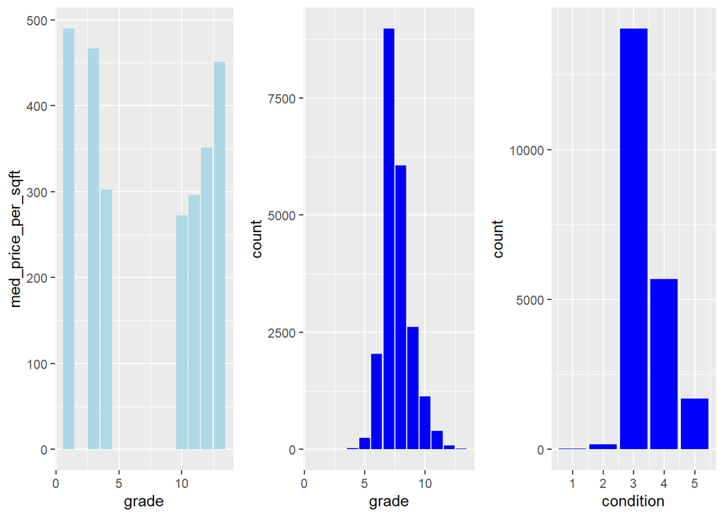

```r
grid.arrange(

houses %>%
  filter(grade %in% grade_filtered) %>%
  mutate(living_sqft_price = price/sqft_living) %>%
  group_by(grade) %>%
    summarise(med_price_per_sqft= median(living_sqft_price)) %>%
    ggplot(mapping = aes(x = grade, y = med_price_per_sqft)) +
      geom_bar(stat = "identity", position = "dodge", fill = "light blue"),

ggplot(data = houses, mapping = aes(grade)) + geom_bar(fill = "blue"),

ggplot(data = houses, mapping = aes(condition)) + geom_bar(fill = "blue"),

ncol = 3
)
```

**Comments**

- The majority of the grade and condition observations are in the middle
  - This means that the odd interactions we keep seeing on the lower end could be extreme outliers

## 7.3 Condition, Median Price per foot, By year built 7.3

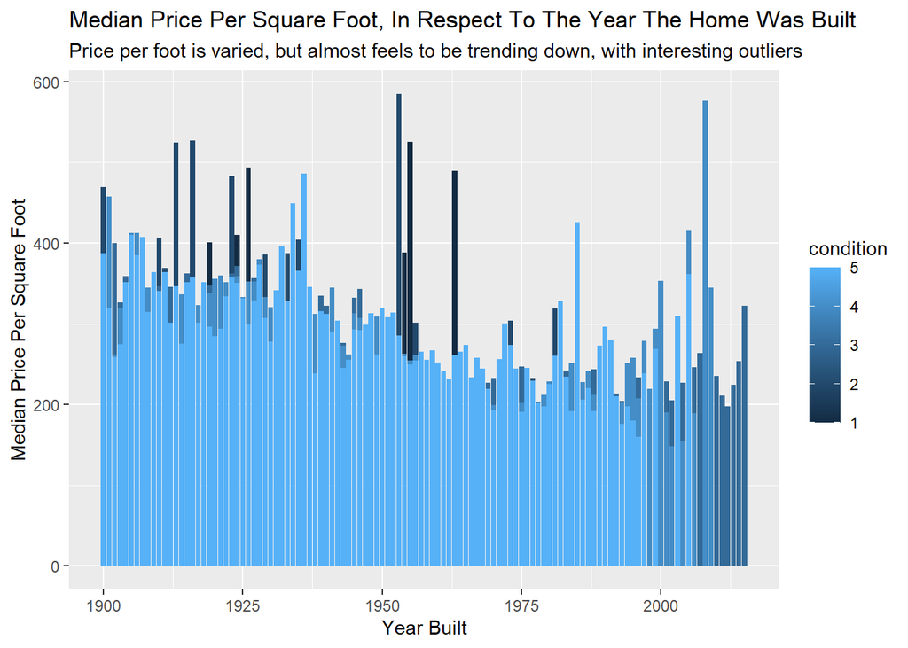

```r
condition_by_year <- houses %>%
  mutate(living_sqft_price = price/sqft_living) %>%
  group_by(yr_built, condition) %>%
  summarise(med_price_per_sqft= median(living_sqft_price)) %>%
  ggplot(mapping = aes(x = yr_built, y = med_price_per_sqft, fill = condition)) +
    geom_bar(stat = "identity", position = "dodge") +
  labs(x = "Year Built", y = "Median Price Per Square Foot", title = "Median Price Per Square Foot, In Respect To The Year The Home Was Built", subtitle = "Price per foot is varied, but almost feels to be trending down, with interesting outliers")
condition_by_year
```

```r
ggsave(filename = "ConditionYrBuilt.png", plot = condition_by_year)
```

**comments**

- Condition can remain excellent despite age
  - there are some extremely old homes that have very good condition
  - there are some very new homes that are in poor condition
  - there are homes that are old, in terrible condition, and sold for a lot **Quesitons**
- things to consider, why did these old homes sell for a lot in poor condition?
  - is it due to value of location?
  - is ther historical value to the homes?